# Kernel Regression Smoothing

```r
library(microbenchmark)
library(Rcpp)
library(ggplot2)
library(tidyr)
```

## Question 1 - Mean KRS

### Data Simulation

Similarly as we’ve seen in the lecture notes, we simulate some data and plot it.
$$y_i = \sin(4\pi x^3) + z_i \qquad \text{where } z_i \sim N(0, 0.04)$$

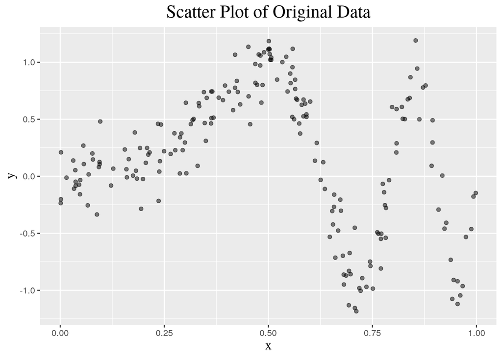

### Kernel Regression Smoother using R

Here’s the Kernel Regression smoother version using R that was proposed in the lecture notes. There’s a minor modification to make it more efficient whereby we calculate `dnorm()` once in each loop iteration rather than twice.

```r
meanKRS <- function(y, x, x0, lam){

 n <- length(x)
 n0 <- length(x0)

 out <- numeric(n0)
 for(ii in 1:n0){
   k = dnorm(x, x0[ii], lam)
  out[ii] <- sum( k * y ) / sum( k )
 }

 return( out )
}
```

We can fit this KRS to our dataset and see the result for different values of $\lambda$.

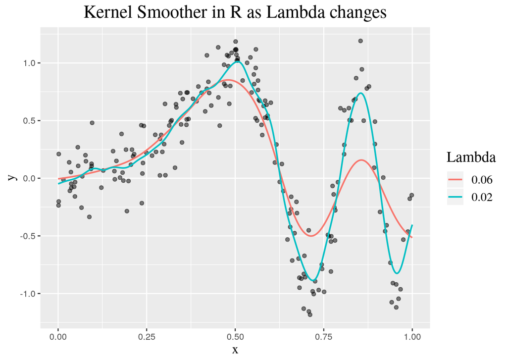

### Kernel Regression Smoother in Rcpp

To import the `Rcpp` version of KRS we source the `Rcpp` file and run it.

```r
sourceCpp("rcpp_functions.cpp")
muSmoothLarge_Rcpp <- meanKRS_Rcpp(y = y, x = x, x0 = xseq, lam = 0.06)
```

We can see that the difference between the `R` version and the `Rcpp` version is very close to `machine precision`.

```r
max(abs(muSmoothLarge - muSmoothLarge_Rcpp))
```

```
## [1] 1.221245e-15
```

Indeed, plotting the result from the `Rcpp` version gives the same plot as the `R` version.

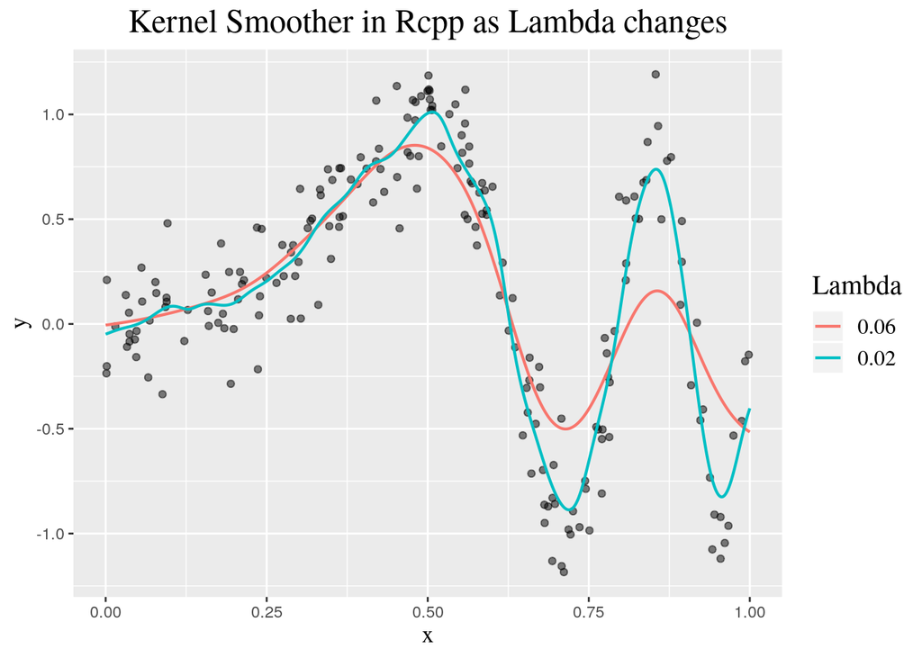

### Benchmarking

```r
library(microbenchmark)
mean_Rcpp <- function() meanKRS_Rcpp(y, x, xseq, 0.06)
mean_R    <- function() meanKRS(y, x, xseq, 0.06)
microbenchmark(R=mean_R(), Rcpp=mean_Rcpp(), unit="relative")
```

```
## Unit: relative
##  expr      min       lq     mean   median       uq    max neval
##     R 1.253347 1.269276 1.275166 1.279368 1.282638 1.1489   100
##  Rcpp 1.000000 1.000000 1.000000 1.000000 1.000000 1.0000   100
```

## Question 2 - Adaptive Kernel Regression Smoothing

### Adaptive KRS in R

The following is a modified version of the `mean_var_KRS()` function seen in class, where `dnorm()` is called once inside each loop, rather than twice, as we’ve seen before.

```r
mean_var_KRS <- function(y, x, x0, lam){

 n <- length(x)
 n0 <- length(x0)
 mu <- res <- numeric(n)

 out <- madHat <- numeric(n0)

 for(ii in 1:n){
   k = dnorm(x, x[ii], lam)
   mu[ii] <- sum( k * y ) / sum( k )
 }

 resAbs <- abs(y - mu)
 for(ii in 1:n0){
   k = dnorm(x, x0[ii], lam)
  madHat[ii] <- sum( k * resAbs ) / sum( k )
 }

 w <- 1 / madHat
 w <- w / mean(w)

 for(ii in 1:n0){
   k = dnorm(x, x0[ii], lam * w[ii])
  out[ii] <- sum( k * y ) /
             sum( k )
 }

 return( out )
}
```

We can look at the results of this function below

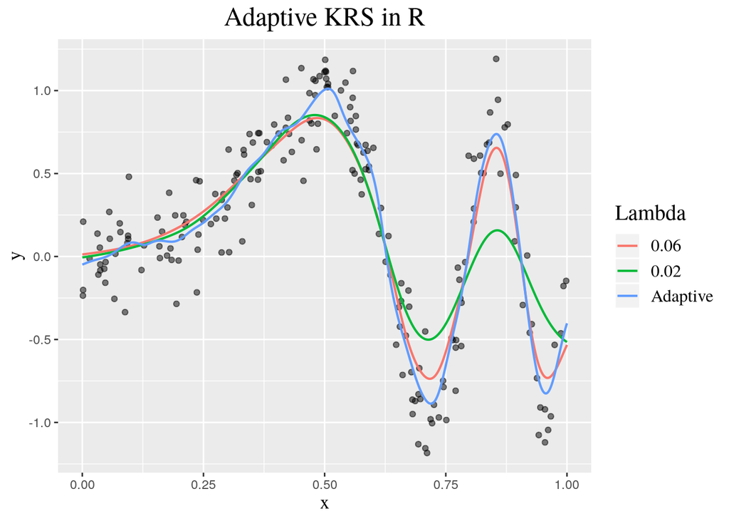

### Adaptive KRS in Rcpp

Similary, we can write an adaptive KRS function in `Rcpp`, source it and compare the result with the `R` version. Again, we see the difference is very close to machine precision.

```r
sourceCpp("rcpp_functions.cpp")
cpp_result = mean_var_KRS_Rcpp(y=y, x=x, x0=xseq, 0.06)
max(abs(cpp_result - r_result))
```

```
## [1] 1.110223e-15
```

In addition, the plot of the results from the Rcpp version is very similar to that of the R version.

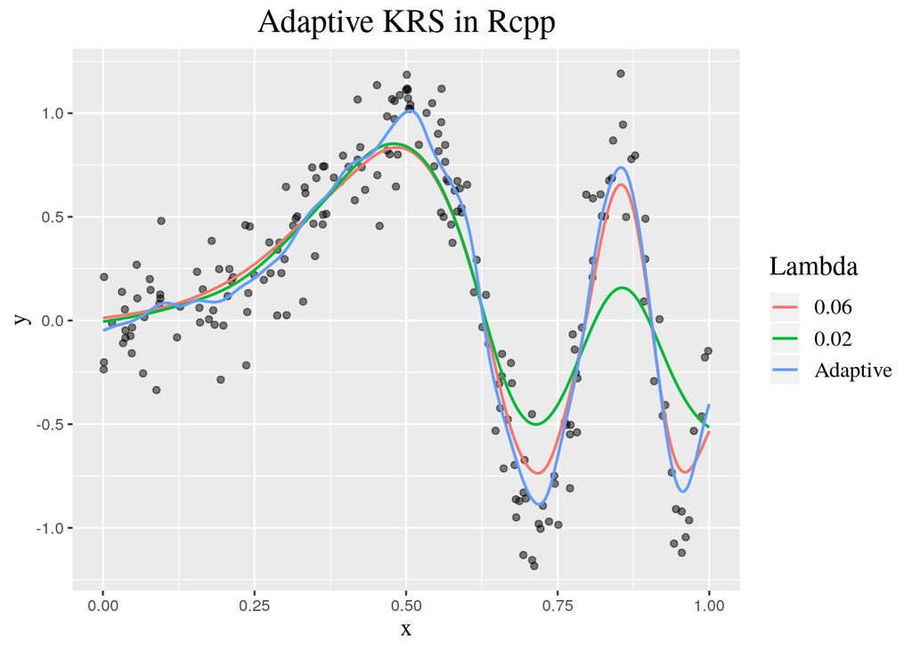

### Benchmarking

We can also microbenchmark them and notice how once again the `Rcpp` function is faster than the `R` counterpart, and it has a similar speed improvement as in the previous question.

```r
microbenchmark(R=mean_var_KRS(y, x, xseq, 0.06), Rcpp=mean_var_KRS_Rcpp(y, x, xseq, 0.06), unit="relative")
```

```
## Unit: relative
##  expr      min       lq     mean   median       uq     max neval
##     R 1.230232 1.236328 1.234261 1.228126 1.220402 1.22533   100
##  Rcpp 1.000000 1.000000 1.000000 1.000000 1.000000 1.00000   100
```

### Cross Validation in R

Below is an `R` implementation of cross-validation.

```r
cvR <- function(x, y, k, lambdas, fun){
  # CREATE FOLD INDECES
  n = length(x)
  fold_indeces_ordered = rep_len(seq(1, k), n)
  fold_indeces = sample(fold_indeces_ordered, n)

  # STORE MEAN MSEs FROM EACH LAMBDA
  all_mean_mses = rep(0, length(lambdas))

  # LOOP THROUGH LAMBDAS
  for (lam_index in 1:length(lambdas)){
    lam = lambdas[lam_index]
    mean_mse = 0.0

    # LOOP THROUGH FOLDS
    for (fold in 1:k){
      is_in_fold = fold_indeces == fold
      # Holdout data
      x_holdout = x[is_in_fold]
      y_holdout = y[is_in_fold]
      # Training data
      x_kept = x[!is_in_fold]
      y_kept = y[!is_in_fold]
      # KRS using holdout as testing set
      krs_value = fun(y_kept, x_kept, x_holdout, lam)
      fold_mse = mean((krs_value - y_holdout)**2)
      # Iteratively compute the mean
      mean_mse = mean_mse + (fold_mse / k)
    }
    all_mean_mses[lam_index] = mean_mse
  }
  return(all_mean_mses)
}
```

We can set some new parameters and data for this specific task.

Then, we can run the `R` version and plot its results.

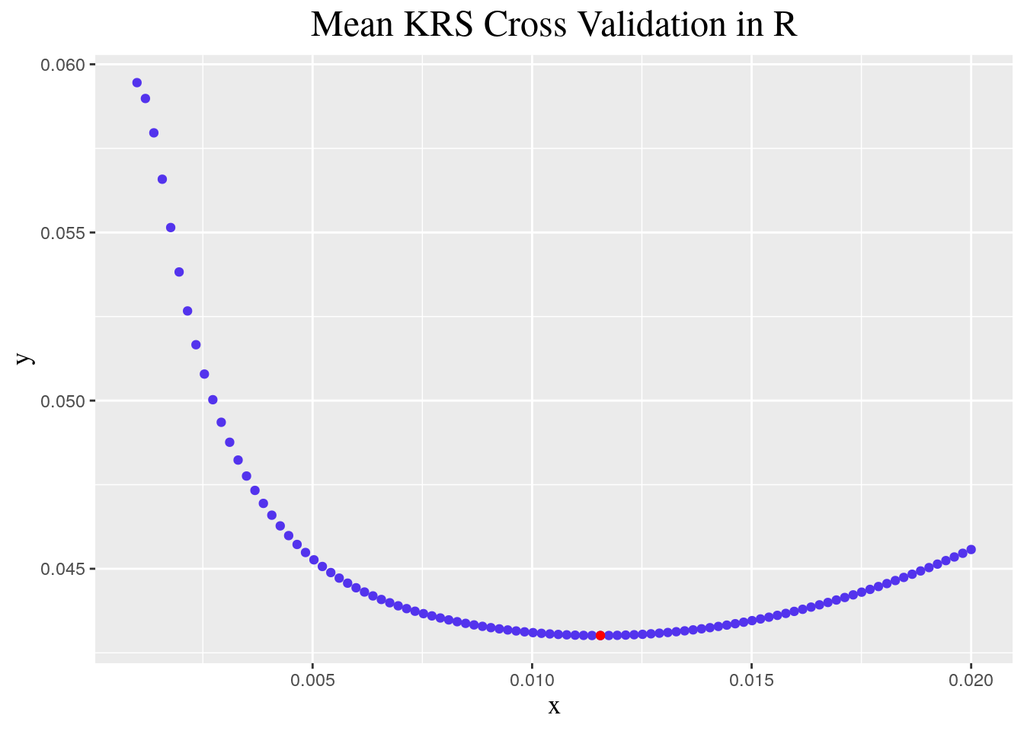

Similarly, we can do the same with Adaptive KRS

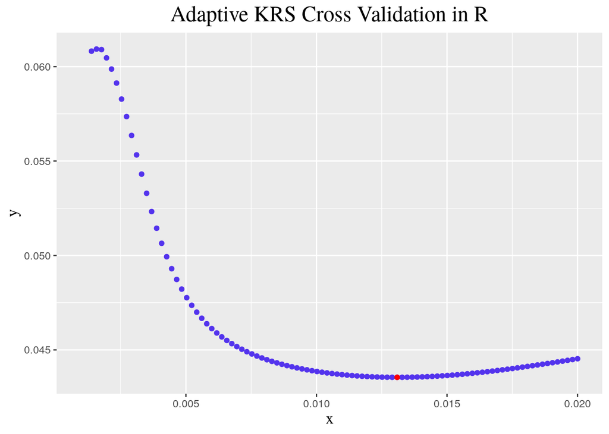

### Cross Validation in Rcpp

Let’s use Cross Validation for the non-adaptive case.

```r
sourceCpp("rcpp_functions.cpp")
Rcpp_cv_result_mean <- crossvalidation_Rcpp(xnew, ynew, k, lambdas, "mean")
```

We can see the results in the following plot.

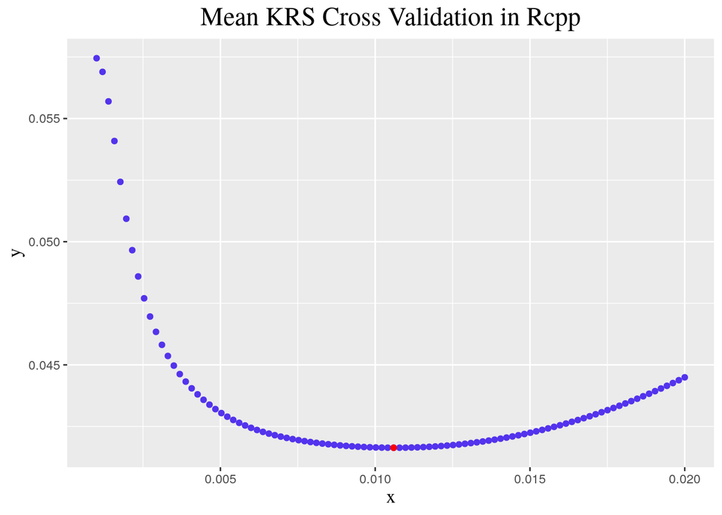

And again, we can do the same for the Adaptive KRS version.

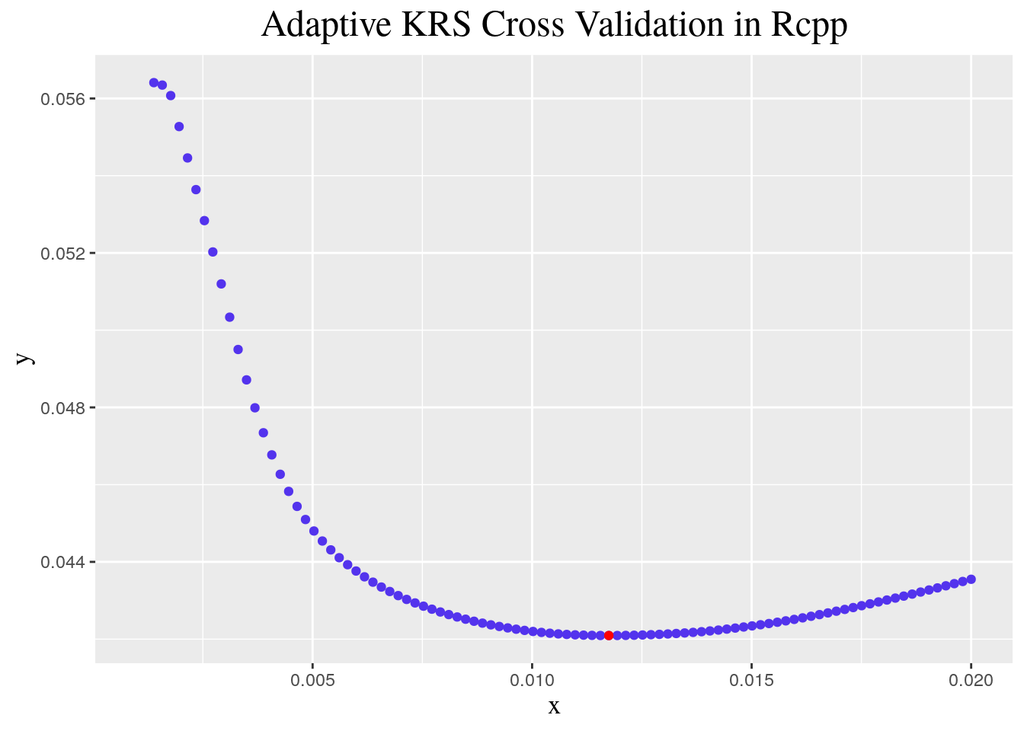

### Benchmarking

We can compare the performance of the full R version with the full Rcpp version.

```r
microbenchmark(
  R_mean   =cvR(xnew, ynew, k, lambdas, meanKRS),
  Rcpp_mean=crossvalidation_Rcpp(xnew, ynew, k, lambdas, "mean"),
  unit="relative", times=50)
```

```
## Unit: relative
##       expr      min     lq     mean   median       uq      max neval
##     R_mean 1.373508 1.3729 1.375148 1.372541 1.382486 1.240854    50
##  Rcpp_mean 1.000000 1.0000 1.000000 1.000000 1.000000 1.000000    50
```

Finally, we compare the performance of CrossValidation on the Adaptive KRS.

```r
microbenchmark(
  R_var   =cvR(xnew, ynew, k, lambdas, mean_var_KRS),
  Rcpp_var=crossvalidation_Rcpp(xnew, ynew, k, lambdas, "var"),
  unit="relative", times=20)
```

```
## Unit: relative
##      expr      min       lq     mean   median       uq      max neval
##     R_var 1.387435 1.382469 1.381087 1.386997 1.387468 1.364144    20
##  Rcpp_var 1.000000 1.000000 1.000000 1.000000 1.000000 1.000000    20
```